# Effects of Borrower's Profile on Their Annual Percentage Rate (APR)

## by (Olatunji Jola)

## Investigation Overview

> In this investigation, I wanted to look at how some particular borrower's profile could be used to predict their Annual Percentage Rate (APR) when they apply for a loan on Prosper Funding LLC platform. The major focus was on basic information like, credit score, employment status, occupation and homeownership status.

## Dataset Overview

> The ProsperLoanData Dataset was put together by Prosper Funding LLC, The first peer to peer online loan company. It contains 113937 observations and 81 variables of loan listing from 2005 to 2014. It provides information on different aspect of the listing that can be broadly divided into three observational units; a concise summary of the loan listing, a detailed profile of the borrower and historical data of previous loan by the same borrower as well as information about the current loan. I filtered out 133 observations due to invalid data entries on their creditscore values.

## Distribution of BorrowerAPR

BorrowerAPR is the Annual Percentage Ratio the borrower pays for the loan. It describes the overall cost of the loan on a yearly basis. The BorrowerAPR in the dataset showed progressive decline in frequency as The APR value increases. The APR ranges between 20% and 40%, with several spikes . It has the highest frequency between 35% and 36%.

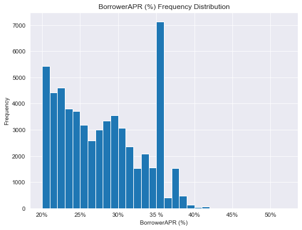

## BorrowerAPR vs. LenderYield vs. EstimatedLoss

The LenderYield is the interest rate on the loan minus the servicing fee. It describes the percentage of interest the Lender eventually makes from entering into the deal with the borrower. In the dataset we can observe a positive correlation of almost 1 (0.989). This means that if the BorrowerAPR is high, The LenderYield is also high.

On the other hand the EstimatedLoss (a measure of how much of the lenders own money is at risk in the event of a chargeoff) also shows a positive correlation with BorrowerAPR, although it has several outlier points at different interval.

The major point of interest of this investigation is how to profile such deals as these outlier points with high BorrowerAPR and low risk.

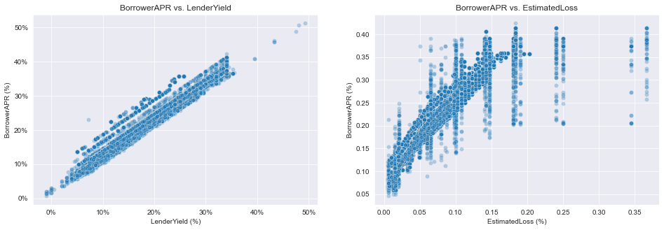

## Distribution of CreditScore

CreditScore is a well known number that defines an individual's access to Loan services and the rate. The credit score are usually defined in ranges to compensate for the different models and vendor values. In this analysis I have settled with the lower range to define a minimum creditscore required for the classification of borrowers. The CreditScore distribution in this dataset is almost a normal distribution, with a slight skew to the left with the modal creditscore value ranging between 660 and 720.

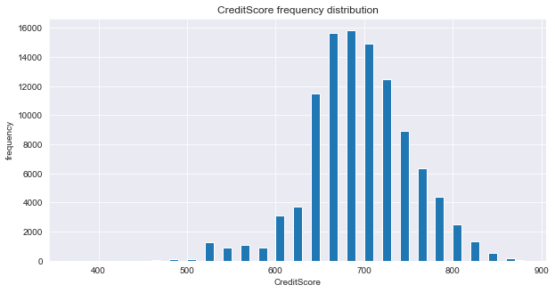

## BorrowerAPR vs. CreditScore

Credit score shows a negative correlation with BorrowerAPR. As CreditScore increases BorrowerAPR reduces, Although there are several outlier points. These again, are points of interest because It suggests that high credit score alone might not suggest a less risky deal.

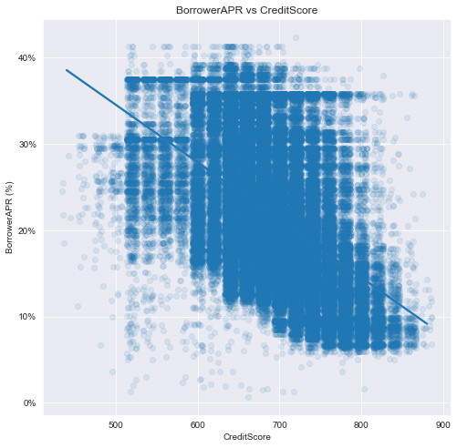

## CreditScore and BorrowerAPR vs. EmploymentStatus

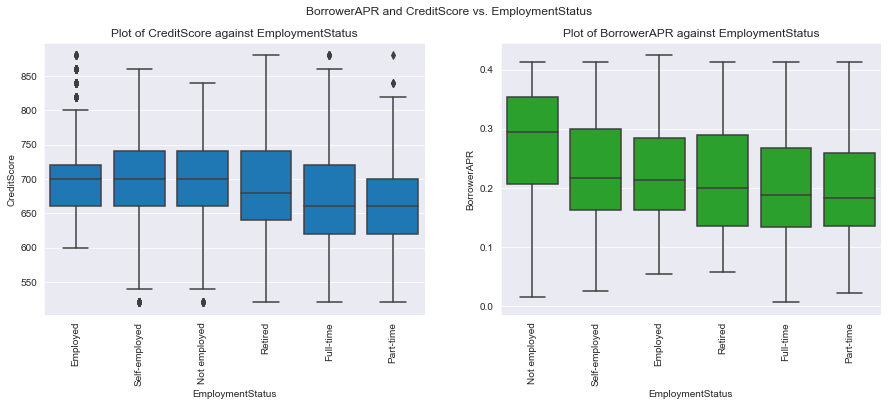

## CreditScore and BorrowerAPR vs. Occupation

#### CreditScore and Occupation

Looking at the CreditScore vs Occupation plot, it can be observed that occupation can be grouped into levels by creditscore. A closer look at the plot reveals that these groups can be identified by the level of skills required to perform such a job. Based on the grouping patterns that was observed I have divided the occupation field into 4 by skill levels.

1. Highly_skilled : contains 4 occupations from Doctor to Investor
2. Skilled: containing 26 occupations from Accountant/CPA to Dentist
3. Semi_skilled: containing 33 occupations from Homemaker to Realtor
4. Students: containing 4 occupations from Student - College Senior to Student - College Sophomore

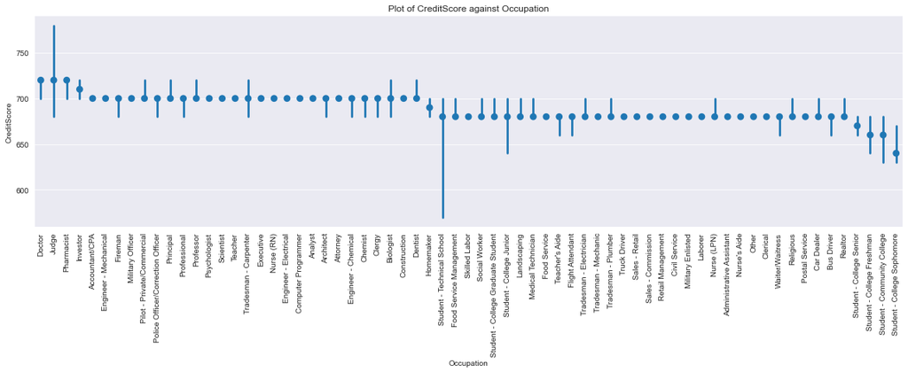

#### BorrowerAPR vs. Occupation.

BorrowerAPR does not follow the same grouping pattern as CreditScore and does not even follow the same order.

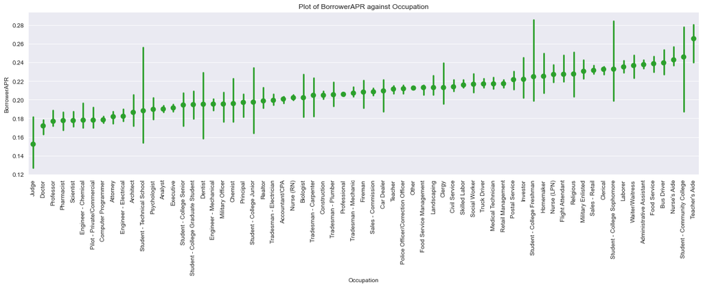

## CreditScore and BorrowerAPR vs. IsBorrowerHomeowner

Generally, those who own homes have higher credit score than those who don't. Also, they get lower APR terms.

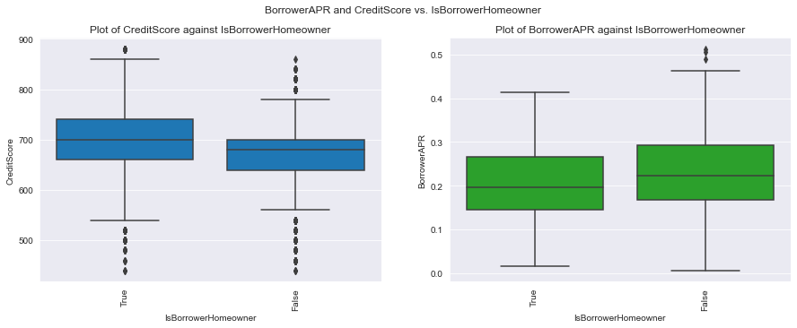

## BorrowerAPR by CreditScore and EmploymentStatus

This plot makes it easy to observe how the BorrowerAPR varies at different CreditScore values for the different EmploymentStatus levels.

**=>** At intermediate CreditScore range (600 > CreditScore <700) Employed and self-employed has the highest APR. This is without respect to Not employed that has the highest APR across the entire range of CreditScore.

**=>** At the higher CreditScore range (>750) Self employed has the highest BorrowerAPR. This is again without respect to Not employed that has the highest APR across the entire range of CreditScore.

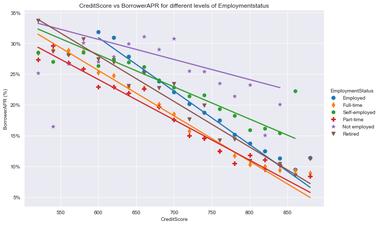

## Considering the effect of IsborrowerHomeowner status on previous plot

**=>** The most notable effect is that, for the groups who have homes,the difference in APR across the different levels of employmentStatus is reduced and the regression lines comes more closely together. Although, the Not employed seem to deviate even wider.

**=>** The groups with homes also have a wider range of CreditScore values, extending well beyond 850 and thereby getting lower APR terms.

**=>** The full-time group now have the least BorrowerAPR across the entire range of CreditScore value.

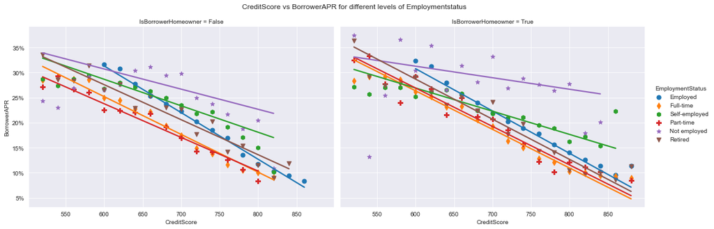

## BorrowerAPR by CreditScore and Occupation_status

**=>** At lower CreditScore values (< 550) Skilled group have the Highest APR values.

**=>** At intermediate CreditScore ranges (600 > CreditScore < 750), It can be observed that there is a convergence among several groups where they have similar APR values.

**=>** At higher CreditScore values(> 750), Semi_skilled have the highest BorrowerAPR.

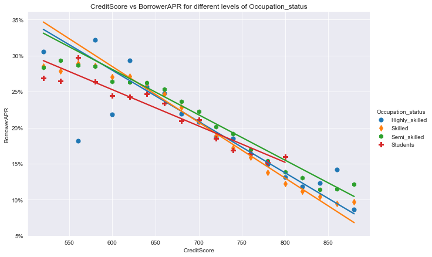

## Considering the effect of IsborrowerHomeowner status on previous plot

**=>** For the groups of homeowners, it can be observed that :

```
   1. Their regression lines comes closer together showing an overall reduction in the difference in the APR.

   2. The creditScore range now extends further well beyond the 850 marks with their attendant lower APR term

   3. Students who own homes and have lower CreditScore values have very high APR. but if their Credit score is greater than 650 they get significantly lowerAPR as compared to other groups.

   4. Highly_skilled and Semi_skilled now have almost parallel regression lines. so that Highly skilled always has lowerAPR terms across all creditscore range.
```

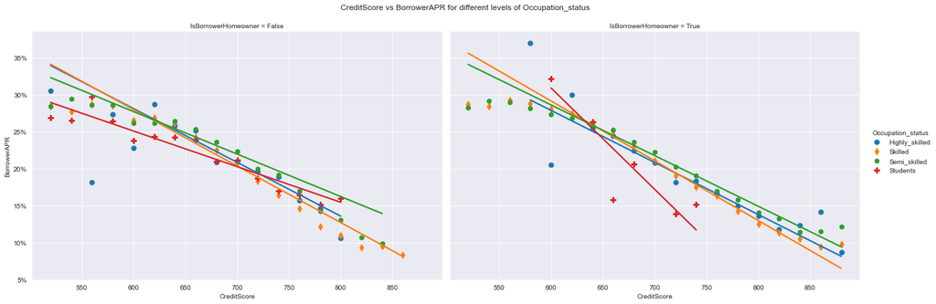